# Risk Factor Analysis

## Outcome Variable

**Outcome Variable:** pers_wast

## Predictor Variables

**Intervention Variable:** month

**Adjustment Set:**

unadjusted

## Stratifying Variables

The analysis was stratified on these variable(s):

- agecat
- studyid
- country

## Data Summary

| agecat | studyid | country | month | pers_wast | n_cell | n |
| --- | --- | --- | --- | --- | --- | --- |
| 0-24 months | CMC-V-BCS-2002 | INDIA | 1 | 0 | 27 | 373 |
| 0-24 months | CMC-V-BCS-2002 | INDIA | 1 | 1 | 1 | 373 |
| 0-24 months | CMC-V-BCS-2002 | INDIA | 2 | 0 | 21 | 373 |
| 0-24 months | CMC-V-BCS-2002 | INDIA | 2 | 1 | 3 | 373 |
| 0-24 months | CMC-V-BCS-2002 | INDIA | 3 | 0 | 23 | 373 |
| 0-24 months | CMC-V-BCS-2002 | INDIA | 3 | 1 | 3 | 373 |
| 0-24 months | CMC-V-BCS-2002 | INDIA | 4 | 0 | 28 | 373 |
| 0-24 months | CMC-V-BCS-2002 | INDIA | 4 | 1 | 1 | 373 |
| 0-24 months | CMC-V-BCS-2002 | INDIA | 5 | 0 | 41 | 373 |
| 0-24 months | CMC-V-BCS-2002 | INDIA | 5 | 1 | 2 | 373 |
| 0-24 months | CMC-V-BCS-2002 | INDIA | 6 | 0 | 33 | 373 |
| 0-24 months | CMC-V-BCS-2002 | INDIA | 6 | 1 | 4 | 373 |
| 0-24 months | CMC-V-BCS-2002 | INDIA | 7 | 0 | 31 | 373 |
| 0-24 months | CMC-V-BCS-2002 | INDIA | 7 | 1 | 2 | 373 |
| 0-24 months | CMC-V-BCS-2002 | INDIA | 8 | 0 | 40 | 373 |
| 0-24 months | CMC-V-BCS-2002 | INDIA | 8 | 1 | 1 | 373 |
| 0-24 months | CMC-V-BCS-2002 | INDIA | 9 | 0 | 22 | 373 |
| 0-24 months | CMC-V-BCS-2002 | INDIA | 9 | 1 | 1 | 373 |
| 0-24 months | CMC-V-BCS-2002 | INDIA | 10 | 0 | 17 | 373 |
| 0-24 months | CMC-V-BCS-2002 | INDIA | 10 | 1 | 2 | 373 |
| 0-24 months | CMC-V-BCS-2002 | INDIA | 11 | 0 | 40 | 373 |
| 0-24 months | CMC-V-BCS-2002 | INDIA | 11 | 1 | 1 | 373 |
| 0-24 months | CMC-V-BCS-2002 | INDIA | 12 | 0 | 27 | 373 |
| 0-24 months | CMC-V-BCS-2002 | INDIA | 12 | 1 | 2 | 373 |
| 0-24 months | CMIN | BANGLADESH | 1 | 0 | 25 | 257 |
| 0-24 months | CMIN | BANGLADESH | 1 | 1 | 3 | 257 |
| 0-24 months | CMIN | BANGLADESH | 2 | 0 | 30 | 257 |
| 0-24 months | CMIN | BANGLADESH | 2 | 1 | 2 | 257 |
| 0-24 months | CMIN | BANGLADESH | 3 | 0 | 20 | 257 |
| 0-24 months | CMIN | BANGLADESH | 3 | 1 | 0 | 257 |

[output cut: 1578 more lines]

The following strata were considered:

- agecat: 0-24 months, studyid: CMC-V-BCS-2002, country: INDIA
- agecat: 0-24 months, studyid: CMIN, country: BANGLADESH
- agecat: 0-24 months, studyid: CONTENT, country: PERU
- agecat: 0-24 months, studyid: EE, country: PAKISTAN
- agecat: 0-24 months, studyid: GMS-Nepal, country: NEPAL
- agecat: 0-24 months, studyid: Guatemala BSC, country: GUATEMALA
- agecat: 0-24 months, studyid: iLiNS-Zinc, country: BURKINA FASO
- agecat: 0-24 months, studyid: IRC, country: INDIA
- agecat: 0-24 months, studyid: Keneba, country: GAMBIA
- agecat: 0-24 months, studyid: LCNI-5, country: MALAWI
- agecat: 0-24 months, studyid: MAL-ED, country: BANGLADESH
- agecat: 0-24 months, studyid: MAL-ED, country: BRAZIL
- agecat: 0-24 months, studyid: MAL-ED, country: INDIA
- agecat: 0-24 months, studyid: MAL-ED, country: NEPAL
- agecat: 0-24 months, studyid: MAL-ED, country: PERU
- agecat: 0-24 months, studyid: MAL-ED, country: SOUTH AFRICA
- agecat: 0-24 months, studyid: MAL-ED, country: TANZANIA, UNITED REPUBLIC OF
- agecat: 0-24 months, studyid: NIH-Birth, country: BANGLADESH
- agecat: 0-24 months, studyid: PROBIT, country: BELARUS
- agecat: 0-24 months, studyid: ResPak, country: PAKISTAN
- agecat: 0-24 months, studyid: SAS-CompFeed, country: INDIA
- agecat: 0-24 months, studyid: SAS-FoodSuppl, country: INDIA
- agecat: 0-24 months, studyid: TanzaniaChild2, country: TANZANIA, UNITED REPUBLIC OF
- agecat: 0-24 months, studyid: ZVITAMBO, country: ZIMBABWE
- agecat: 0-6 months, studyid: CMC-V-BCS-2002, country: INDIA
- agecat: 0-6 months, studyid: CMIN, country: BANGLADESH
- agecat: 0-6 months, studyid: CONTENT, country: PERU
- agecat: 0-6 months, studyid: EE, country: PAKISTAN
- agecat: 0-6 months, studyid: GMS-Nepal, country: NEPAL
- agecat: 0-6 months, studyid: IRC, country: INDIA
- agecat: 0-6 months, studyid: Keneba, country: GAMBIA
- agecat: 0-6 months, studyid: MAL-ED, country: BANGLADESH
- agecat: 0-6 months, studyid: MAL-ED, country: BRAZIL
- agecat: 0-6 months, studyid: MAL-ED, country: INDIA
- agecat: 0-6 months, studyid: MAL-ED, country: NEPAL
- agecat: 0-6 months, studyid: MAL-ED, country: PERU
- agecat: 0-6 months, studyid: MAL-ED, country: SOUTH AFRICA
- agecat: 0-6 months, studyid: MAL-ED, country: TANZANIA, UNITED REPUBLIC OF
- agecat: 0-6 months, studyid: NIH-Birth, country: BANGLADESH
- agecat: 0-6 months, studyid: PROBIT, country: BELARUS
- agecat: 0-6 months, studyid: ResPak, country: PAKISTAN
- agecat: 0-6 months, studyid: TanzaniaChild2, country: TANZANIA, UNITED REPUBLIC OF
- agecat: 0-6 months, studyid: ZVITAMBO, country: ZIMBABWE
- agecat: 6-24 months, studyid: CMC-V-BCS-2002, country: INDIA
- agecat: 6-24 months, studyid: CMIN, country: BANGLADESH
- agecat: 6-24 months, studyid: CONTENT, country: PERU
- agecat: 6-24 months, studyid: EE, country: PAKISTAN
- agecat: 6-24 months, studyid: GMS-Nepal, country: NEPAL
- agecat: 6-24 months, studyid: Guatemala BSC, country: GUATEMALA
- agecat: 6-24 months, studyid: iLiNS-Zinc, country: BURKINA FASO
- agecat: 6-24 months, studyid: IRC, country: INDIA
- agecat: 6-24 months, studyid: Keneba, country: GAMBIA
- agecat: 6-24 months, studyid: LCNI-5, country: MALAWI
- agecat: 6-24 months, studyid: MAL-ED, country: BANGLADESH
- agecat: 6-24 months, studyid: MAL-ED, country: BRAZIL
- agecat: 6-24 months, studyid: MAL-ED, country: INDIA
- agecat: 6-24 months, studyid: MAL-ED, country: NEPAL
- agecat: 6-24 months, studyid: MAL-ED, country: PERU
- agecat: 6-24 months, studyid: MAL-ED, country: SOUTH AFRICA
- agecat: 6-24 months, studyid: MAL-ED, country: TANZANIA, UNITED REPUBLIC OF
- agecat: 6-24 months, studyid: NIH-Birth, country: BANGLADESH
- agecat: 6-24 months, studyid: PROBIT, country: BELARUS
- agecat: 6-24 months, studyid: ResPak, country: PAKISTAN
- agecat: 6-24 months, studyid: SAS-CompFeed, country: INDIA
- agecat: 6-24 months, studyid: SAS-FoodSuppl, country: INDIA
- agecat: 6-24 months, studyid: TanzaniaChild2, country: TANZANIA, UNITED REPUBLIC OF
- agecat: 6-24 months, studyid: ZVITAMBO, country: ZIMBABWE

### Dropped Strata

Some strata were dropped due to rare outcomes:

- agecat: 0-24 months, studyid: CMC-V-BCS-2002, country: INDIA
- agecat: 0-24 months, studyid: CMIN, country: BANGLADESH
- agecat: 0-24 months, studyid: CONTENT, country: PERU
- agecat: 0-24 months, studyid: EE, country: PAKISTAN
- agecat: 0-24 months, studyid: GMS-Nepal, country: NEPAL
- agecat: 0-24 months, studyid: Guatemala BSC, country: GUATEMALA
- agecat: 0-24 months, studyid: IRC, country: INDIA
- agecat: 0-24 months, studyid: LCNI-5, country: MALAWI
- agecat: 0-24 months, studyid: MAL-ED, country: BANGLADESH
- agecat: 0-24 months, studyid: MAL-ED, country: BRAZIL
- agecat: 0-24 months, studyid: MAL-ED, country: INDIA
- agecat: 0-24 months, studyid: MAL-ED, country: NEPAL
- agecat: 0-24 months, studyid: MAL-ED, country: PERU
- agecat: 0-24 months, studyid: MAL-ED, country: SOUTH AFRICA
- agecat: 0-24 months, studyid: MAL-ED, country: TANZANIA, UNITED REPUBLIC OF
- agecat: 0-24 months, studyid: NIH-Birth, country: BANGLADESH
- agecat: 0-24 months, studyid: ResPak, country: PAKISTAN
- agecat: 0-24 months, studyid: SAS-CompFeed, country: INDIA
- agecat: 0-24 months, studyid: SAS-FoodSuppl, country: INDIA
- agecat: 0-24 months, studyid: TanzaniaChild2, country: TANZANIA, UNITED REPUBLIC OF
- agecat: 0-6 months, studyid: CMC-V-BCS-2002, country: INDIA
- agecat: 0-6 months, studyid: CMIN, country: BANGLADESH
- agecat: 0-6 months, studyid: CONTENT, country: PERU
- agecat: 0-6 months, studyid: EE, country: PAKISTAN
- agecat: 0-6 months, studyid: GMS-Nepal, country: NEPAL
- agecat: 0-6 months, studyid: IRC, country: INDIA
- agecat: 0-6 months, studyid: Keneba, country: GAMBIA
- agecat: 0-6 months, studyid: MAL-ED, country: BANGLADESH
- agecat: 0-6 months, studyid: MAL-ED, country: BRAZIL
- agecat: 0-6 months, studyid: MAL-ED, country: INDIA
- agecat: 0-6 months, studyid: MAL-ED, country: NEPAL
- agecat: 0-6 months, studyid: MAL-ED, country: PERU
- agecat: 0-6 months, studyid: MAL-ED, country: SOUTH AFRICA
- agecat: 0-6 months, studyid: MAL-ED, country: TANZANIA, UNITED REPUBLIC OF
- agecat: 0-6 months, studyid: NIH-Birth, country: BANGLADESH
- agecat: 0-6 months, studyid: ResPak, country: PAKISTAN
- agecat: 0-6 months, studyid: TanzaniaChild2, country: TANZANIA, UNITED REPUBLIC OF
- agecat: 0-6 months, studyid: ZVITAMBO, country: ZIMBABWE
- agecat: 6-24 months, studyid: CMC-V-BCS-2002, country: INDIA
- agecat: 6-24 months, studyid: CMIN, country: BANGLADESH
- agecat: 6-24 months, studyid: CONTENT, country: PERU
- agecat: 6-24 months, studyid: EE, country: PAKISTAN
- agecat: 6-24 months, studyid: GMS-Nepal, country: NEPAL
- agecat: 6-24 months, studyid: Guatemala BSC, country: GUATEMALA
- agecat: 6-24 months, studyid: IRC, country: INDIA
- agecat: 6-24 months, studyid: LCNI-5, country: MALAWI
- agecat: 6-24 months, studyid: MAL-ED, country: BANGLADESH
- agecat: 6-24 months, studyid: MAL-ED, country: BRAZIL
- agecat: 6-24 months, studyid: MAL-ED, country: INDIA
- agecat: 6-24 months, studyid: MAL-ED, country: NEPAL
- agecat: 6-24 months, studyid: MAL-ED, country: PERU
- agecat: 6-24 months, studyid: MAL-ED, country: SOUTH AFRICA
- agecat: 6-24 months, studyid: MAL-ED, country: TANZANIA, UNITED REPUBLIC OF
- agecat: 6-24 months, studyid: NIH-Birth, country: BANGLADESH
- agecat: 6-24 months, studyid: ResPak, country: PAKISTAN
- agecat: 6-24 months, studyid: SAS-CompFeed, country: INDIA
- agecat: 6-24 months, studyid: SAS-FoodSuppl, country: INDIA
- agecat: 6-24 months, studyid: TanzaniaChild2, country: TANZANIA, UNITED REPUBLIC OF

## Methods Detail

We’re interested in the causal parameters $E[Y_a]$ for all values of $a \in \mathcal{A}$. These parameters represent the mean outcome if, possibly contrary to fact, we intervened to set all units to have $A=a$. Under the randomization and positivity assumptions, these are identified by the statistical parameters $\psi_a=E_W[E_{Y|A,W}(Y|A=a,W)]$. In addition, we’re interested in the mean of $Y$, $E[Y]$ under no intervention (the observed mean). We will estimate these parameters by using SuperLearner to fit the relevant likelihood factors – $E_{Y|A,W}(Y|A=a,W)$ and $p(A=a|W)$, and then updating our likelihood fit using a joint TMLE.

For unadjusted analyses ($W=\{\}$), initial likelihoods were estimated using Lrnr_glm to estimate the simple $E(Y|A)$ and Lrnr_mean to estimate $p(A)$. For adjusted analyses, a small library containing Lrnr_glmnet, Lrnr_xgboost, and Lrnr_mean was used.

Having estimated these parameters, we will then use the delta method to estimate relative risks and attributable risks relative to a prespecified baseline level of $A$.

# Results Detail

## Results Plots

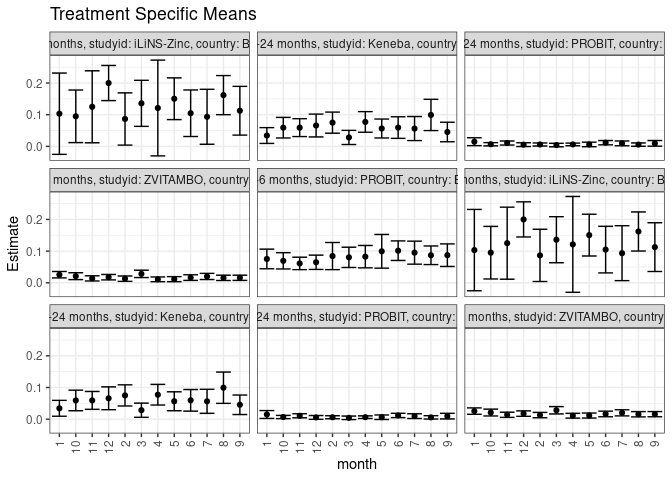

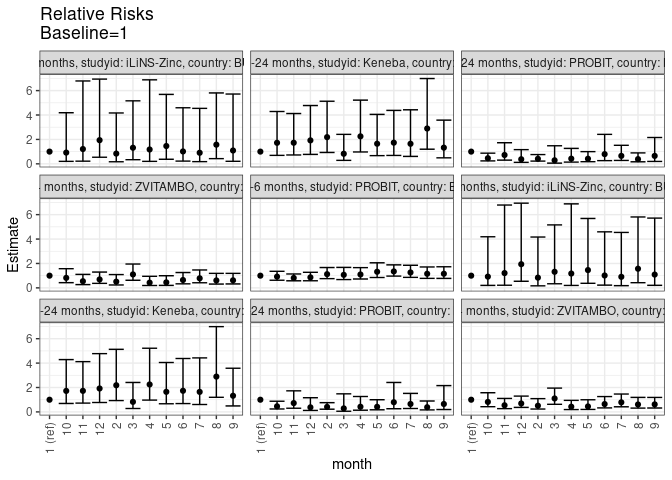

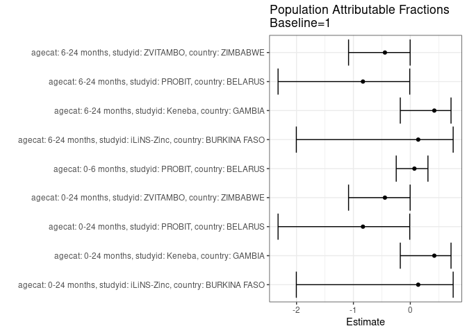

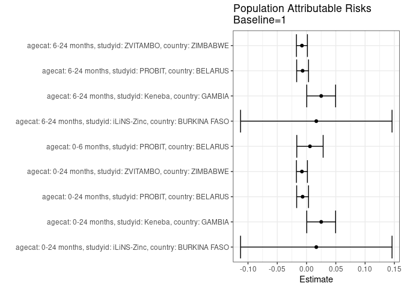

## Results Table

### Parameter: TSM

| agecat | studyid | country | intervention_level | baseline_level | estimate | ci_lower | ci_upper |
| --- | --- | --- | --- | --- | --- | --- | --- |
| 0-24 months | iLiNS-Zinc | BURKINA FASO | 1 | NA | 0.1031746 | -0.0251156 | 0.2314648 |
| 0-24 months | iLiNS-Zinc | BURKINA FASO | 2 | NA | 0.0865385 | 0.0041394 | 0.1689376 |
| 0-24 months | iLiNS-Zinc | BURKINA FASO | 3 | NA | 0.1359223 | 0.0632883 | 0.2085564 |
| 0-24 months | iLiNS-Zinc | BURKINA FASO | 4 | NA | 0.1212121 | -0.0299747 | 0.2723989 |
| 0-24 months | iLiNS-Zinc | BURKINA FASO | 5 | NA | 0.1504425 | 0.0845608 | 0.2163241 |
| 0-24 months | iLiNS-Zinc | BURKINA FASO | 6 | NA | 0.1047120 | 0.0312439 | 0.1781802 |
| 0-24 months | iLiNS-Zinc | BURKINA FASO | 7 | NA | 0.0934579 | 0.0067666 | 0.1801493 |
| 0-24 months | iLiNS-Zinc | BURKINA FASO | 8 | NA | 0.1619048 | 0.1001995 | 0.2236101 |
| 0-24 months | iLiNS-Zinc | BURKINA FASO | 9 | NA | 0.1125828 | 0.0356469 | 0.1895187 |
| 0-24 months | iLiNS-Zinc | BURKINA FASO | 10 | NA | 0.0950000 | 0.0120340 | 0.1779660 |
| 0-24 months | iLiNS-Zinc | BURKINA FASO | 11 | NA | 0.1250000 | 0.0113568 | 0.2386432 |
| 0-24 months | iLiNS-Zinc | BURKINA FASO | 12 | NA | 0.2000000 | 0.1445744 | 0.2554256 |
| 0-24 months | Keneba | GAMBIA | 1 | NA | 0.0343137 | 0.0093290 | 0.0592984 |
| 0-24 months | Keneba | GAMBIA | 2 | NA | 0.0750000 | 0.0416702 | 0.1083298 |
| 0-24 months | Keneba | GAMBIA | 3 | NA | 0.0283019 | 0.0059743 | 0.0506295 |
| 0-24 months | Keneba | GAMBIA | 4 | NA | 0.0772201 | 0.0447038 | 0.1097364 |
| 0-24 months | Keneba | GAMBIA | 5 | NA | 0.0565217 | 0.0266716 | 0.0863719 |
| 0-24 months | Keneba | GAMBIA | 6 | NA | 0.0594595 | 0.0253755 | 0.0935434 |
| 0-24 months | Keneba | GAMBIA | 7 | NA | 0.0563380 | 0.0184064 | 0.0942697 |
| 0-24 months | Keneba | GAMBIA | 8 | NA | 0.0992908 | 0.0499195 | 0.1486620 |
| 0-24 months | Keneba | GAMBIA | 9 | NA | 0.0454545 | 0.0146746 | 0.0762345 |
| 0-24 months | Keneba | GAMBIA | 10 | NA | 0.0591133 | 0.0266644 | 0.0915622 |
| 0-24 months | Keneba | GAMBIA | 11 | NA | 0.0592593 | 0.0310905 | 0.0874280 |
| 0-24 months | Keneba | GAMBIA | 12 | NA | 0.0659341 | 0.0298725 | 0.1019957 |
| 0-24 months | PROBIT | BELARUS | 1 | NA | 0.0148084 | 0.0023870 | 0.0272298 |
| 0-24 months | PROBIT | BELARUS | 2 | NA | 0.0060852 | 0.0012619 | 0.0109085 |
| 0-24 months | PROBIT | BELARUS | 3 | NA | 0.0042772 | -0.0012425 | 0.0097968 |
| 0-24 months | PROBIT | BELARUS | 4 | NA | 0.0062612 | 0.0020978 | 0.0104245 |
| 0-24 months | PROBIT | BELARUS | 5 | NA | 0.0061837 | -0.0009440 | 0.0133115 |
| 0-24 months | PROBIT | BELARUS | 6 | NA | 0.0117548 | 0.0050145 | 0.0184951 |

[output cut: 78 more lines]

### Parameter: E(Y)

| agecat | studyid | country | intervention_level | baseline_level | estimate | ci_lower | ci_upper |
| --- | --- | --- | --- | --- | --- | --- | --- |
| 0-24 months | iLiNS-Zinc | BURKINA FASO | NA | NA | 0.1198322 | 0.0943748 | 0.1452897 |
| 0-24 months | Keneba | GAMBIA | NA | NA | 0.0593290 | 0.0499611 | 0.0686968 |
| 0-24 months | PROBIT | BELARUS | NA | NA | 0.0080806 | 0.0045539 | 0.0116073 |
| 0-24 months | ZVITAMBO | ZIMBABWE | NA | NA | 0.0176341 | 0.0149910 | 0.0202771 |
| 0-6 months | PROBIT | BELARUS | NA | NA | 0.0810551 | 0.0555982 | 0.1065120 |
| 6-24 months | iLiNS-Zinc | BURKINA FASO | NA | NA | 0.1198322 | 0.0943748 | 0.1452897 |
| 6-24 months | Keneba | GAMBIA | NA | NA | 0.0593290 | 0.0499611 | 0.0686968 |
| 6-24 months | PROBIT | BELARUS | NA | NA | 0.0080806 | 0.0045539 | 0.0116073 |
| 6-24 months | ZVITAMBO | ZIMBABWE | NA | NA | 0.0176341 | 0.0149910 | 0.0202771 |

### Parameter: RR

| agecat | studyid | country | intervention_level | baseline_level | estimate | ci_lower | ci_upper |
| --- | --- | --- | --- | --- | --- | --- | --- |
| 0-24 months | iLiNS-Zinc | BURKINA FASO | 1 | 1 | 1.0000000 | 1.0000000 | 1.0000000 |
| 0-24 months | iLiNS-Zinc | BURKINA FASO | 2 | 1 | 0.8387574 | 0.1688395 | 4.1667615 |
| 0-24 months | iLiNS-Zinc | BURKINA FASO | 3 | 1 | 1.3174010 | 0.3363297 | 5.1602512 |
| 0-24 months | iLiNS-Zinc | BURKINA FASO | 4 | 1 | 1.1748252 | 0.2005119 | 6.8834522 |
| 0-24 months | iLiNS-Zinc | BURKINA FASO | 5 | 1 | 1.4581348 | 0.3738117 | 5.6877752 |
| 0-24 months | iLiNS-Zinc | BURKINA FASO | 6 | 1 | 1.0149013 | 0.2242300 | 4.5936085 |
| 0-24 months | iLiNS-Zinc | BURKINA FASO | 7 | 1 | 0.9058231 | 0.1805737 | 4.5439377 |
| 0-24 months | iLiNS-Zinc | BURKINA FASO | 8 | 1 | 1.5692308 | 0.4238967 | 5.8091633 |
| 0-24 months | iLiNS-Zinc | BURKINA FASO | 9 | 1 | 1.0911870 | 0.2082314 | 5.7181057 |
| 0-24 months | iLiNS-Zinc | BURKINA FASO | 10 | 1 | 0.9207692 | 0.2024908 | 4.1869367 |
| 0-24 months | iLiNS-Zinc | BURKINA FASO | 11 | 1 | 1.2115385 | 0.2162089 | 6.7889224 |
| 0-24 months | iLiNS-Zinc | BURKINA FASO | 12 | 1 | 1.9384615 | 0.5414145 | 6.9404003 |
| 0-24 months | Keneba | GAMBIA | 1 | 1 | 1.0000000 | 1.0000000 | 1.0000000 |
| 0-24 months | Keneba | GAMBIA | 2 | 1 | 2.1857143 | 0.9313833 | 5.1293028 |
| 0-24 months | Keneba | GAMBIA | 3 | 1 | 0.8247978 | 0.2819056 | 2.4131886 |
| 0-24 months | Keneba | GAMBIA | 4 | 1 | 2.2504137 | 0.9704416 | 5.2186157 |
| 0-24 months | Keneba | GAMBIA | 5 | 1 | 1.6472050 | 0.6700479 | 4.0493885 |
| 0-24 months | Keneba | GAMBIA | 6 | 1 | 1.7328185 | 0.6859549 | 4.3773434 |
| 0-24 months | Keneba | GAMBIA | 7 | 1 | 1.6418511 | 0.6090335 | 4.4261522 |
| 0-24 months | Keneba | GAMBIA | 8 | 1 | 2.8936170 | 1.1981721 | 6.9881609 |
| 0-24 months | Keneba | GAMBIA | 9 | 1 | 1.3246753 | 0.4900875 | 3.5805132 |
| 0-24 months | Keneba | GAMBIA | 10 | 1 | 1.7227305 | 0.6921526 | 4.2877833 |
| 0-24 months | Keneba | GAMBIA | 11 | 1 | 1.7269841 | 0.7238463 | 4.1203142 |
| 0-24 months | Keneba | GAMBIA | 12 | 1 | 1.9215071 | 0.7729422 | 4.7767988 |
| 0-24 months | PROBIT | BELARUS | 1 | 1 | 1.0000000 | 1.0000000 | 1.0000000 |
| 0-24 months | PROBIT | BELARUS | 2 | 1 | 0.4109295 | 0.2228558 | 0.7577234 |
| 0-24 months | PROBIT | BELARUS | 3 | 1 | 0.2888341 | 0.0563384 | 1.4807855 |
| 0-24 months | PROBIT | BELARUS | 4 | 1 | 0.4228138 | 0.1414522 | 1.2638303 |
| 0-24 months | PROBIT | BELARUS | 5 | 1 | 0.4175847 | 0.1745407 | 0.9990618 |
| 0-24 months | PROBIT | BELARUS | 6 | 1 | 0.7937966 | 0.2609658 | 2.4145431 |

[output cut: 78 more lines]

### Parameter: PAR

| agecat | studyid | country | intervention_level | baseline_level | estimate | ci_lower | ci_upper |
| --- | --- | --- | --- | --- | --- | --- | --- |
| 0-24 months | iLiNS-Zinc | BURKINA FASO | 1 | NA | 0.0166576 | -0.1127007 | 0.1460159 |
| 0-24 months | Keneba | GAMBIA | 1 | NA | 0.0250152 | 0.0003620 | 0.0496685 |
| 0-24 months | PROBIT | BELARUS | 1 | NA | -0.0067278 | -0.0168368 | 0.0033812 |
| 0-24 months | ZVITAMBO | ZIMBABWE | 1 | NA | -0.0078707 | -0.0172736 | 0.0015322 |
| 0-6 months | PROBIT | BELARUS | 1 | NA | 0.0058495 | -0.0166608 | 0.0283598 |
| 6-24 months | iLiNS-Zinc | BURKINA FASO | 1 | NA | 0.0166576 | -0.1127007 | 0.1460159 |
| 6-24 months | Keneba | GAMBIA | 1 | NA | 0.0250152 | 0.0003620 | 0.0496685 |
| 6-24 months | PROBIT | BELARUS | 1 | NA | -0.0067278 | -0.0168368 | 0.0033812 |
| 6-24 months | ZVITAMBO | ZIMBABWE | 1 | NA | -0.0078707 | -0.0172736 | 0.0015322 |

### Parameter: PAF

| agecat | studyid | country | intervention_level | baseline_level | estimate | ci_lower | ci_upper |
| --- | --- | --- | --- | --- | --- | --- | --- |
| 0-24 months | iLiNS-Zinc | BURKINA FASO | 1 | NA | 0.1390079 | -2.0034569 | 0.7531820 |
| 0-24 months | Keneba | GAMBIA | 1 | NA | 0.4216362 | -0.1762285 | 0.7156125 |
| 0-24 months | PROBIT | BELARUS | 1 | NA | -0.8325901 | -2.3245453 | -0.0101792 |
| 0-24 months | ZVITAMBO | ZIMBABWE | 1 | NA | -0.4463337 | -1.0853600 | -0.0031271 |
| 0-6 months | PROBIT | BELARUS | 1 | NA | 0.0721667 | -0.2476426 | 0.3099990 |
| 6-24 months | iLiNS-Zinc | BURKINA FASO | 1 | NA | 0.1390079 | -2.0034569 | 0.7531820 |
| 6-24 months | Keneba | GAMBIA | 1 | NA | 0.4216362 | -0.1762285 | 0.7156125 |
| 6-24 months | PROBIT | BELARUS | 1 | NA | -0.8325901 | -2.3245453 | -0.0101792 |
| 6-24 months | ZVITAMBO | ZIMBABWE | 1 | NA | -0.4463337 | -1.0853600 | -0.0031271 |